# Trabajo Mineria de dada

Todo El Grupo

24/9/2021

# 1 Estructura de base de dadas

```r
# Leer base de dada
data<-read.csv(paste0(params$path,'/',params$data.origin))

# n.observacions y n.variables
dim(data)
```

```
[1] 119390     32
```

```r
#nombre de cada variable
names(data)
```

```
 [1] "hotel"                          "is_canceled"
 [3] "lead_time"                      "arrival_date_year"
 [5] "arrival_date_month"             "arrival_date_week_number"
 [7] "arrival_date_day_of_month"      "stays_in_weekend_nights"
 [9] "stays_in_week_nights"           "adults"
[11] "children"                       "babies"
[13] "meal"                           "country"
[15] "market_segment"                 "distribution_channel"
[17] "is_repeated_guest"              "previous_cancellations"
[19] "previous_bookings_not_canceled" "reserved_room_type"
[21] "assigned_room_type"             "booking_changes"
[23] "deposit_type"                   "agent"
[25] "company"                        "days_in_waiting_list"
[27] "customer_type"                  "adr"
[29] "required_car_parking_spaces"    "total_of_special_requests"
[31] "reservation_status"             "reservation_status_date"
```

# 1.1 Filtre de bases de dada

```r
# solo seleccionando clientes de España
d.e<-data[data$country=='ESP',names(data)!='country']
name<-names(d.e)

# Descrpcion por la nova bases de dadas
n<-list(total=prod(dim(d.e)))
n$observation<-nrow(d.e)
n$variable<-ncol(d.e)
n
```

```
$total
[1] 265608

$observation
[1] 8568

$variable
[1] 31
```

# 1.2 Descripcion de datos faltantes

```r
# missings
d.e[d.e=='NULL']<-NA
mis<-sapply(d.e,function(x) sum(is.na(x)))
v.mis<-which(mis>0)
mis<-mis[mis>0]
n$missing<-sum(mis)
mis<-list(count=list(number=n$missing,forvar=mis),
          relative=list(forall=n$missing/n$total,formissing=mis/n$missing,
                        forvar=mis/n$observation))
mis
```

```
$count
$count$number
[1] 9051

$count$forvar
  agent company
    720    8331


$relative
$relative$forall
[1] 0.03407653

$relative$formissing
     agent    company
0.07954922 0.92045078

$relative$forvar
     agent    company
0.08403361 0.97233894
```

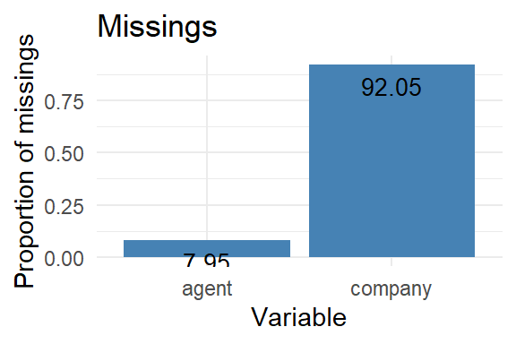

```r
library(ggplot2)
missing <- data.frame(prop=mis$relative$formissing, variable=names(mis$relative$formissing))
p<-ggplot(data=missing, aes(x=variable, y=prop)) +
   geom_bar(stat="identity", fill = "steelblue") +
   geom_text(aes(label=round(prop*100,2)), vjust=1.6, color="black", size=3.5) +
   theme_minimal() +
   labs(x = "Variable", y = "Proportion of missings", title = "Missings")
p
```

# 1.3 Decralacion de variables

```r
# definir tipus de variables
v<-list(
  categoric=c('is_canceled','hotel','arrival_date_year','arrival_date_month','meal',
              'market_segment','distribution_channel','is_repeated_guest','reserved_room_type',
              'assigned_room_type','deposit_type','agent','company','customer_type',
              'reservation_status'),
  integer=c('lead_time','arrival_date_week_number','arrival_date_day_of_month',
            'stays_in_weekend_nights','stays_in_week_nights','adults','children','babies',
            'previous_cancellations','previous_bookings_not_canceled','booking_changes',
            'days_in_waiting_list','required_car_parking_spaces','total_of_special_requests'),
  continua='adr',
  times='reservation_status_date'
        )
v$numeric<-c(v$integer,v$continua,v$times)
v$withmissing<-v.mis

# decraracion de variables
for(i in v$categoric) d.e[[i]]<-as.factor(d.e[[i]])
for(i in v$integer) d.e[[i]]<-as.integer(d.e[[i]])
for(i in v$times) d.e[[i]]<-as.Date(d.e[[i]])
levels(d.e$arrival_date_month)<-c("January", "February" ,"March", "April","May",
                                  "June" , "July", "August"  , "September" ,
                                  "November" , "October", "December")
levels(d.e$reserved_room_type)<-levels(d.e$assigned_room_type)
```

# 2 Descriptiva de base de dadas

```
Variable categoric
```

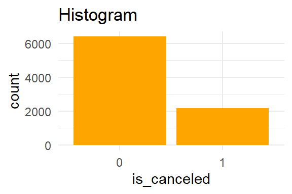

```
   0    1
6391 2177
```

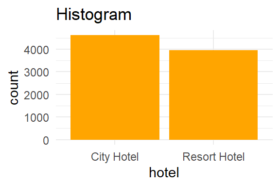

```
  City Hotel Resort Hotel
        4611         3957
```

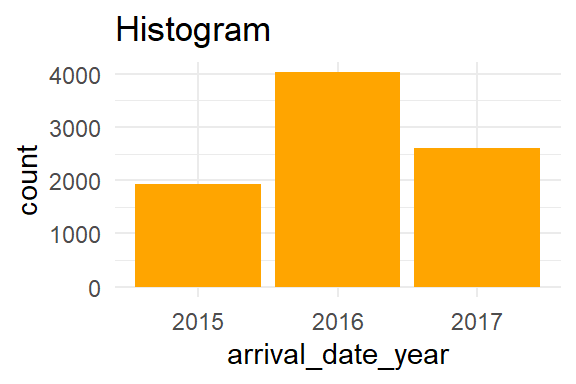

```
2015 2016 2017
1932 4024 2612
```

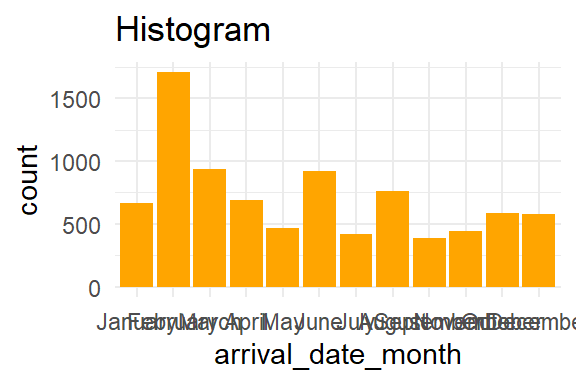

```
  January  February     March     April       May      June      July    August
      670      1705       935       692       466       921       417       761
September  November   October  December
      391       442       590       578
```

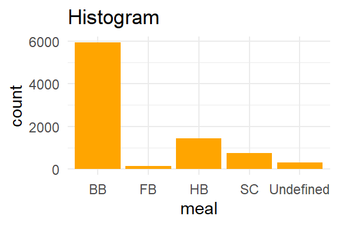

```
       BB        FB        HB        SC Undefined
     5939       143      1438       751       297
```

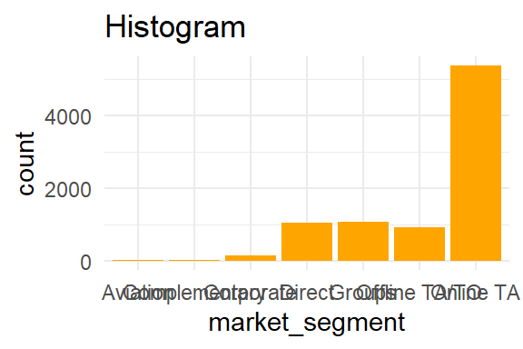

```
     Aviation Complementary     Corporate        Direct        Groups
           13            12           153          1047          1064
Offline TA/TO     Online TA
          910          5369
```

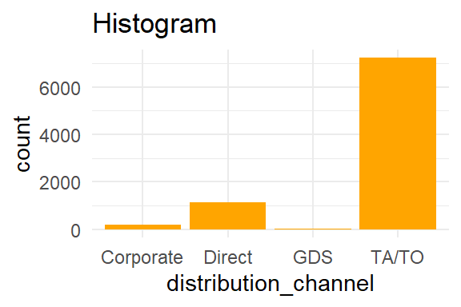

```
Corporate    Direct       GDS     TA/TO
      183      1125        35      7225
```

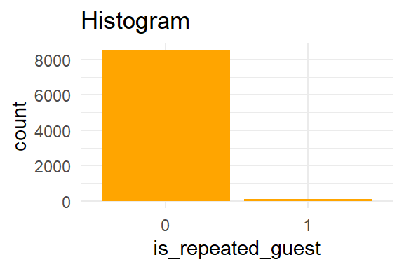

```
   0    1
8478   90
```

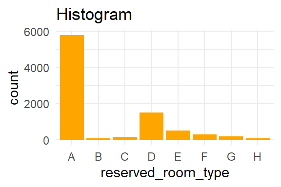

```
   A    B    C    D    E    F    G    H    I    K
5770   77  147 1508  507  295  186   78    0    0
```

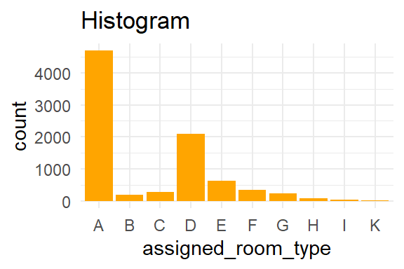

```
   A    B    C    D    E    F    G    H    I    K
4689  183  281 2093  622  352  227   82   27   12
```

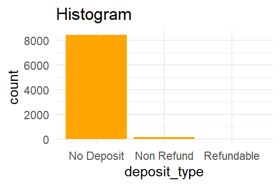

```
No Deposit Non Refund Refundable
      8431        131          6
```

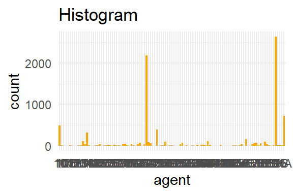

```
      9     240       1     250      14       6      38     134      28      83
   2635    2188     486     384     321     155     105     103     101      91
    241     314       7     196      68     242       8     177      19     195
     87      76      70      66      62      57      56      50      37      35
     52      85     313      15      67     138      22     175     350     159
     35      34      33      32      32      31      30      29      27      25
    387      42     339     348     155      10     142     147     171       5
     25      25      19      17      16      14      14      14      14      14
     13     281     156     168      86     468     191     152     153      89
     13      12      10      10      10       9       8       6       6       6
    149     290     441      98     324     375      95     115     127     184
      5       5       5       5       4       4       4       3       3       3
    254     258     335      77      91     106     151     157       3     306
      3       3       3       3       3       2       2       2       2       2
    327     334     336      39     414     425     429     436      63      66
      2       2       2       2       2       2       2       2       2       2
     87     104     105     118      12     126     143     146     174     187
      2       1       1       1       1       1       1       1       1       1
    193      20     243     248     253     280     298     315 (Other)    NA's
      1       1       1       1       1       1       1       1       8     720
```

[19 more figures not shown]

```
        Min.      1st Qu.       Median         Mean      3rd Qu.         Max.
"2015-05-16" "2016-02-03" "2016-08-04" "2016-07-29" "2017-02-02" "2017-09-09"
```

```r
for(j in 1:4){
  cat('Variable',names(v)[j],'\n')
  color<-c('orange','steelblue','red','limegreen')[j]
  for(i in v[[j]]){
    cat('\n\n')
    print(ggplot(d.e, aes(x=d.e[[i]])) + geom_bar(stat = "count", fill=color,na.rm = T)+
          theme_minimal() +
          labs(title = "Histogram")+xlab(i))
    print(summary(d.e[[i]]))
  }
}
```

# 3 Preprocessing

## 3.1 Missing

Los missing que tengamos est?n en las variables company y agent, la cuales no son falta de respuestas sino que indica si un cliente hizo la resrva a trav?s de una agencia o no en el caso de agent, an?logamente con la variabel company Asi que eliminamos las variables company y agent pero a?adimos dos variable restype que inidca si es una reserva hecha por agente o compa??a o no

```r
d.e$is_company<-factor(ifelse(is.na(d.e$company),0,1))
d.e$is_agent<-factor(ifelse(is.na(d.e$agent),0,1))
v.elimina<-which(names(d.e) %in% c('company','agent'))
d.e<-d.e[,-v.elimina]
```

## 3.2 Creacion de nuevas variables

Creamos una nueva variable, si la habitaci?n reservada se corresponde con la habitaci?n asignada o no, Creemos qu esto puede tener m?s relevancia que el tipo de habitaciones que no conocemos debido a que es an?nimo

```r
d.e$room_coherence<-factor(d.e$reserved_room_type == d.e$assigned_room_type)
```

Creamos las variables si ha cancelalato , si ha asignado y si han estat algun dia a la llista d’espera o no anteriorment

```r
d.e$if_prev_cancel<-factor(d.e$previous_cancellations>0)
d.e$if_prev_asign<-factor(d.e$previous_bookings_not_canceled>0)
d.e$if_wait<-factor(d.e$days_in_waiting_list>0)
```

## 3.3 Multicolinealidad y Outlier

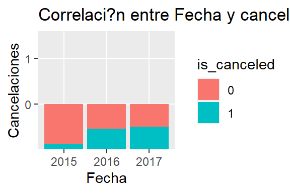

```r
ggplot(d.e, aes(x = arrival_date_year, fill = is_canceled, y = is_canceled)) + geom_col(position = 'fill' ) +ggtitle("Correlaci?n entre Fecha y cancelaci?n")+ labs(y="Cancelaciones", x = "Fecha")
```

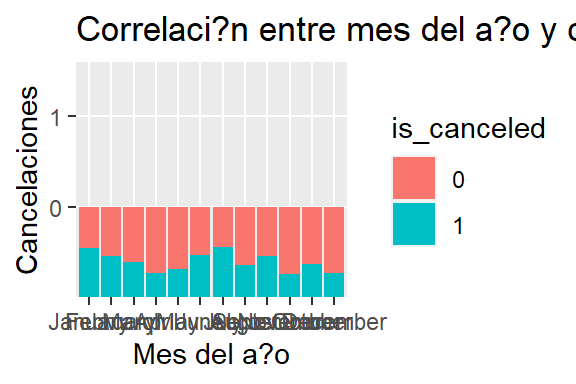

```r
ggplot(d.e, aes(x = arrival_date_month, fill = is_canceled, y = is_canceled)) + geom_col(position = "fill")+ggtitle("Correlaci?n entre mes del a?o y cancelaci?n")+ labs(y="Cancelaciones", x = "Mes del a?o")
```

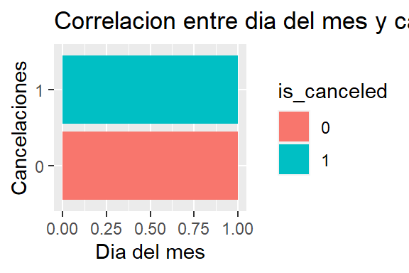

```r
ggplot(d.e, aes(x = arrival_date_day_of_month, fill = is_canceled, y = is_canceled)) + geom_col(position = "fill")+ggtitle("Correlacion entre dia del mes y cancelacion")+ labs(y="Cancelaciones", x = "Dia del mes")
```

Nos fijamos que nuestra variable respuesta esta igualmente distribuida en la variable arrival_date_day_of_month por lo que no aporta informacion nueva Sin embargo, la variable que hacer referencia al año si que es relevante, no obstante no la tendremos en cuenta ya que valoramos que no es interesante para los modelos que estudiaremos

Como que no tiene mucha diferencia entre numero de semanas y meses dentro un año, eliminamos tambien el numero de semanas

```r
summary(d.e[,c('is_canceled','reservation_status')])
```

```
 is_canceled reservation_status
 0:6391      Canceled :2145
 1:2177      Check-Out:6391
             No-Show  :  32
```

La variable reservation_status tiene misma informacion que la nuestra variable explicativa asi que la eliminamos

```r
v.elimina<-which(names(d.e) %in% c('reservation_status_date','arrival_date_week_number',
             'arrival_date_day_of_month','reservation_status'))
d.e<-d.e[,-v.elimina]
```

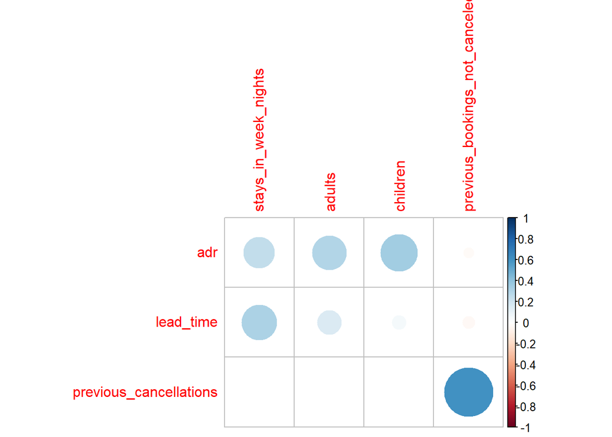

```r
corr<-cor(d.e[,v$numeric])
corr[ col(corr)<=row(corr) ]<-0
corr<-corr[!apply(corr, 1, function(x) all(abs(x)<0.2)),!apply(corr, 2, function(x) all(abs(x)<0.2))]
corrplot::corrplot(corr)
```

Visto la alta correlacion entre previous_cancellations y previous_bookings_not_canceled, decidimos que eliminamos el previous_bookings_not_canceled, y logicamente el if_prev_asign tambien

```r
d.e<-d.e[,!names(d.e)%in%c('previous_bookings_not_canceled','if_prev_asign','previous_cancellations','days_in_waiting_list')]
```

# 4 Analisi Descriptiva Prossecada

## 4.1 Analisi Descriptiva univariante

```
Variable categoric
```

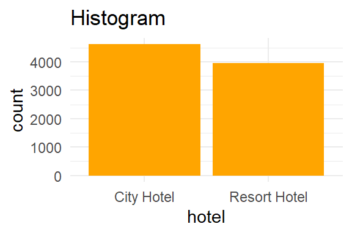

```
  City Hotel Resort Hotel
        4611         3957
```

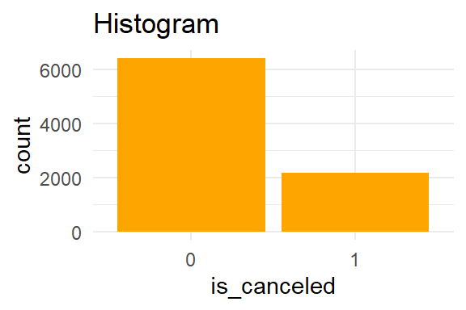

```
   0    1
6391 2177
```

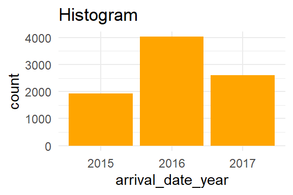

```
2015 2016 2017
1932 4024 2612
```

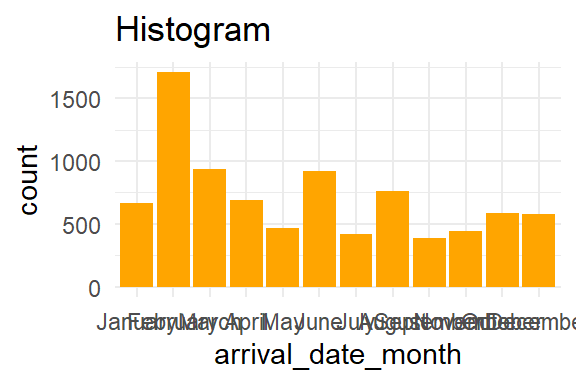

```
  January  February     March     April       May      June      July    August
      670      1705       935       692       466       921       417       761
September  November   October  December
      391       442       590       578
```

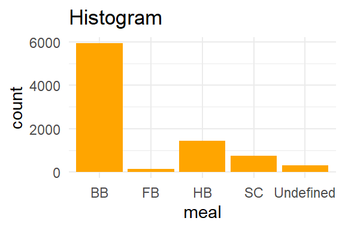

```
       BB        FB        HB        SC Undefined
     5939       143      1438       751       297
```

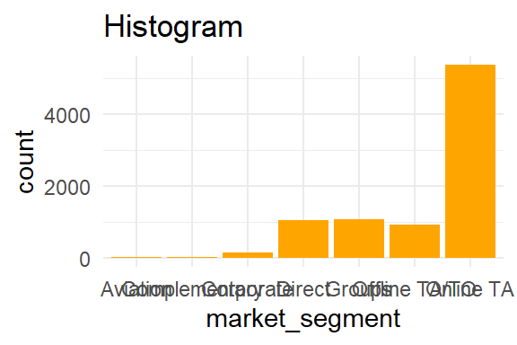

```
     Aviation Complementary     Corporate        Direct        Groups
           13            12           153          1047          1064
Offline TA/TO     Online TA
          910          5369
```

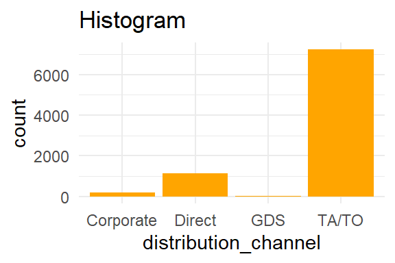

```
Corporate    Direct       GDS     TA/TO
      183      1125        35      7225
```

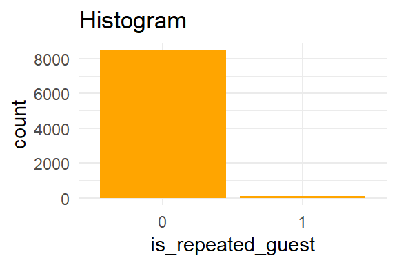

```
   0    1
8478   90
```

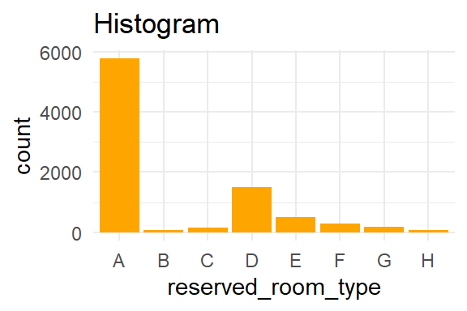

```
   A    B    C    D    E    F    G    H    I    K
5770   77  147 1508  507  295  186   78    0    0
```

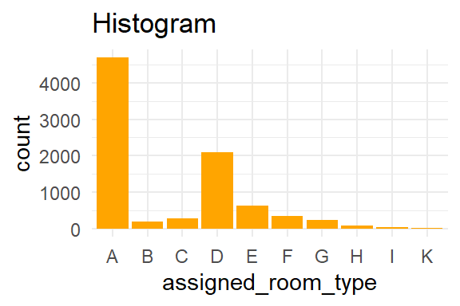

```
   A    B    C    D    E    F    G    H    I    K
4689  183  281 2093  622  352  227   82   27   12
```

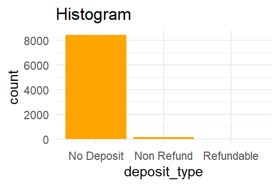

```
No Deposit Non Refund Refundable
      8431        131          6
```

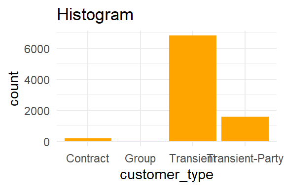

```
       Contract           Group       Transient Transient-Party
            170              25            6802            1571
```

[15 more figures not shown]

```
   Min. 1st Qu.  Median    Mean 3rd Qu.    Max.
    0.0    75.0   104.5   117.0   150.0   402.0
```

```r
for(j in 1:3){
  cat('Variable',names(v)[j],'\n')
  color<-c('orange','steelblue','red')[j]
  for(i in v[[j]]){
    cat('\n\n')
    print(ggplot(d.e, aes(x=d.e[[i]])) + geom_bar(stat = "count", fill=color)+
          theme_minimal() +
          labs(title = "Histogram")+xlab(names(d.e)[i]))
    print(summary(d.e[[i]]))
  }
}
```

## 4.2 Analisi Descriptiva Bivariante

```
Variable categoric
```

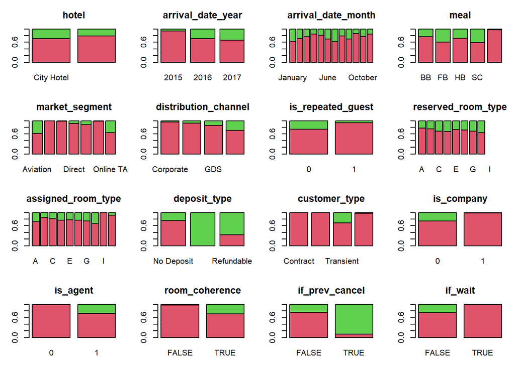

```
Variable integer
```

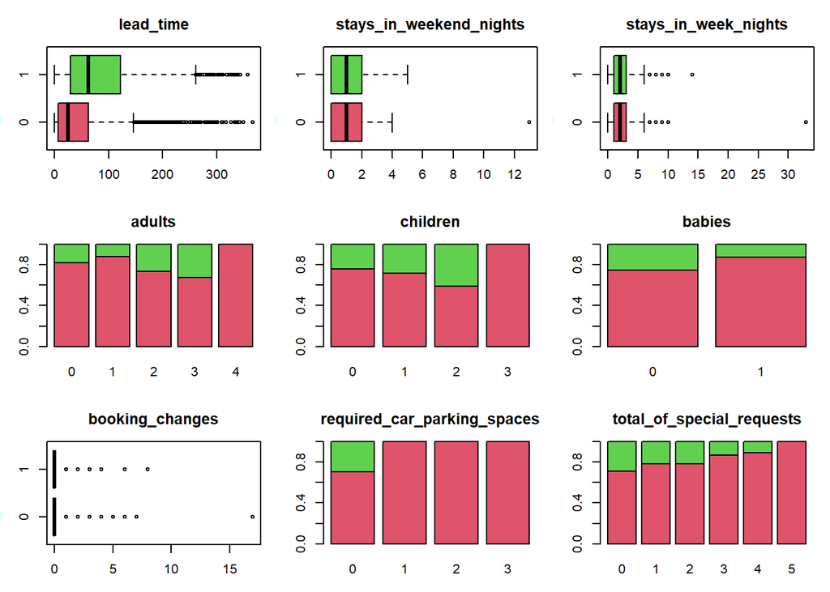

```
Variable continua
```

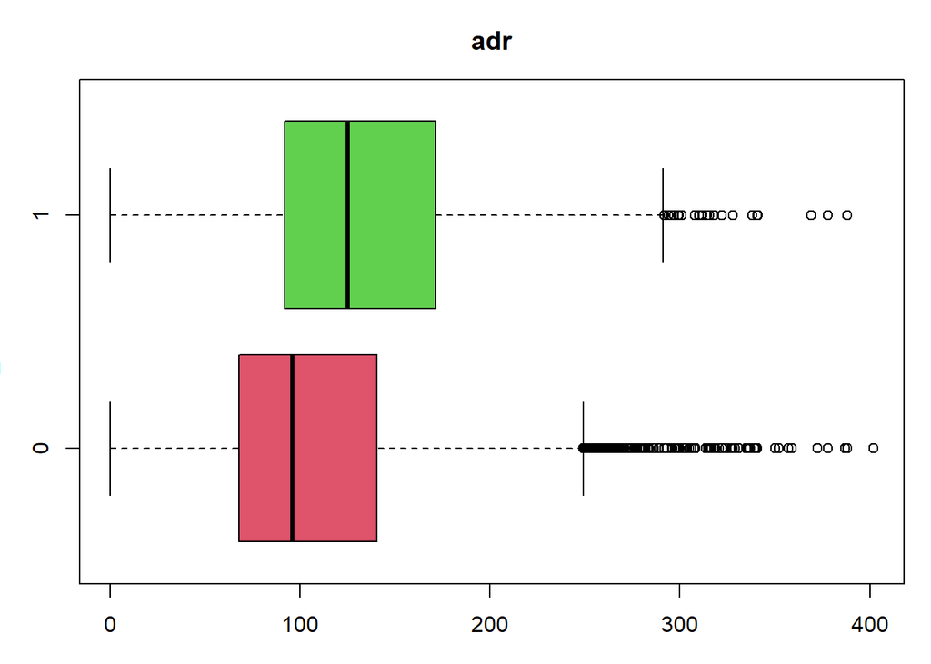

```r
for(j in 1:3){
  cat('Variable',names(v)[j],'\n')
  color<-c('orange','steelblue','red')[j]
  par(mfrow=rep(c(4,3,1)[j],2),mar=c(3,3,3,1))
  for(i in names(d.e)[v[[j]]]){
    cat('\n\n')
    if (j==1){
      if(i=='is_canceled') next
      barplot(prop.table(table(d.e$is_canceled, d.e[[i]]),2),main=i,col=c(2,3))
    }else if(j==2){
      if(max(d.e[[i]])>10) boxplot(as.formula(paste0(i,"~is_canceled")),d.e,main=i,col=c(2,3),horizontal=T)
      else barplot(prop.table(table(d.e$is_canceled, d.e[[i]]),2),main=i,col=c(2,3))
    }else boxplot(as.formula(paste0(i,"~is_canceled")),d.e,main=i,col=c(2,3),horizontal=T)
  }
}
```